# MODEL DIAGNOSTICS & SPATIAL AUTOCORRELATION

WEEK 7 IN-CLASS LAB

Author

Tess Vu

Published

October 21, 2025

# Homework Feedback & Tips

## Before We Start: A Quick Note on Your Submissions

**We noticed something in your homework submissions…**

Many of you have **messy output** in your rendered HTML files from `tigris` and `tidycensus` functions.

**Example of what we’re seeing:**

```
Downloading: 4.3 MB
Downloading: 3.7 MB
```

**This clutters your professional report!**

## The Problem: Progress Bars in Rendered Output

**What’s happening:**

When you use `tigris` or `tidycensus` functions, they show download progress by default.

### **In your console (good!):**

```r
tracts <- get_acs(
  geography = "tract",
  variables = "B01003_001",
  state = "PA",
  geometry = TRUE
)
```

**This is helpful when coding!**

### **In your rendered HTML (bad!):**

All those progress messages appear as ugly text in your final document.

**This looks unprofessional** and makes your work harder to read.

**Solution:** Suppress progress messages in your code chunks

## The Solution: Add `progress = FALSE`

**Two ways to fix this:**

### **Option 1: In each function call**

```r
# Add progress = FALSE to EVERY tigris/tidycensus call
tracts <- get_acs(
  geography = "tract",
  variables = "B01003_001",
  state = "PA",
  geometry = TRUE,
  progress = FALSE  # <-- Add this!
)

roads <- roads(state = "PA",
               county = "Philadelphia",
               progress = FALSE)  # <-- Add this!
```

### **Option 2: Set globally at top of document** (Recommended!)

```r
# Add this near the top of your .qmd after loading libraries
options(tigris_use_cache = TRUE)
options(tigris_progress = FALSE)  # Suppress tigris progress bars
```

## Action Required: Re-Render Before Final Grading

**Important**📝 To-Do Before We Grade**

**Please go back to your homework and:**

1. Open your `.qmd` file
2. Add `progress = FALSE` to all `get_acs()`, `get_decennial()`, and `tigris` function calls
   - OR add the global options at the top of your document
3. **Re-render** your document (Click “Render” button)
4. Check that the HTML output is clean
5. **Re-submit** on Canvas if needed (but it should all update on your website once you re-render!)

**Deadline:** Before our next class meeting

**Why this matters:** We gotta look good!

# Today’s Plan

## Agenda Overview

**Part 1: Review & Connect**

- Where we’ve been and where we’re going
- The regression workflow so far

**Part 2: Evaluating Model Quality**

- Train/test splits vs. cross-validation review
- Spatial patterns in errors
- Introduction to spatial autocorrelation

**Part 3: Moran’s I as a Diagnostic**

**BREAK (10 min)**

**Part 4: Midterm Work Session (90+ min)**

# Part 1: Where We Are

## The Journey So Far

**Weeks 1-3:** Data foundations

- Census data, tidycensus, spatial data basics
- Visualization and exploratory analysis

**Week 5:** Linear regression fundamentals

- Y = f(X) + ε framework
- Train/test splits, cross-validation
- Checking assumptions

**Week 6:** Expanding the toolkit

- Categorical variables and interactions
- Spatial features (buffers, kNN, distance)
- Neighborhood fixed effects

## Last Week’s Key Innovation

**You learned to create spatial features:**

```r
# Buffer aggregation
crimes_500ft <- count_features_in_buffer(houses, crimes, 500)

# k-Nearest Neighbors
crime_nn3 <- average_distance_to_knn(houses, crimes, k=3)

# Fixed effects
lm(SalePrice ~ ... + as.factor(neighborhood))
```

**Today’s Question:**

> *How do we know if our model still has spatial structure in its errors?*

If errors are spatially clustered, we’re missing something important!

## The Regression Workflow (Updated)

**Building the model:**

1. Visualize relationships
2. Engineer features
3. Fit the model
4. Evaluate performance (RMSE, R²)
5. Check assumptions

**NEW: Spatial diagnostics:**

6. **Are errors random or clustered?**
7. **Do we predict better in some areas?**
8. **Is there remaining spatial structure?**

**ImportantWhy This Matters**

If errors cluster spatially, it suggests:

- Missing spatial variables
- Misspecified relationships
- Non-stationarity (relationships vary across space)

# Part 2: Understanding Spatial Patterns in Errors

## What Are Model Errors?

**Prediction error** for observation *i*:

$$e_i = \hat{y}_i - y_i$$

Where:

- $\hat{y}_i$ = predicted value
- $y_i$ = actual value

**In our house price context:**

```r
# Load packages and data
library(sf)
library(here)
library(tidyverse)

# Load Boston housing data
boston <- read_csv(here("data/boston.csv"))

# Simple model: Predict price from living area
baseline_model <- lm(SalePrice ~ LivingArea, data = boston)
summary(baseline_model)
```

```
Call:
lm(formula = SalePrice ~ LivingArea, data = boston)

Residuals:
    Min      1Q  Median      3Q     Max
-855962 -219491  -68291   55248 9296561

Coefficients:
             Estimate Std. Error t value Pr(>|t|)
(Intercept) 157968.32   35855.59   4.406 1.13e-05 ***
LivingArea     216.54      14.47  14.969  < 2e-16 ***
---
Signif. codes:  0 '***' 0.001 '**' 0.01 '*' 0.05 '.' 0.1 ' ' 1

Residual standard error: 563800 on 1483 degrees of freedom
Multiple R-squared:  0.1313,    Adjusted R-squared:  0.1307
F-statistic: 224.1 on 1 and 1483 DF,  p-value: < 2.2e-16
```

```r
boston_test <- boston %>%
  mutate(
    predicted = predict(baseline_model, boston),
    error = predicted - SalePrice,
    abs_error = abs(error),
    pct_error = abs(error) / SalePrice
  )
```

## Good Errors vs. Bad Errors

** Random errors (good)**

- No systematic pattern
- Scattered across space
- Prediction equally good everywhere
- Model captures key relationships

** Clustered errors (bad)**

- Spatial pattern visible
- Under/over-predict in areas
- Model misses something about location
- Need more spatial features!

**How do we test this?**

Look for **spatial autocorrelation** in the errors

## Tobler’s First Law (Revisited)

**NoteThe First Law of Geography**

*“Everything is related to everything else, but near things are more related than distant things.”*

— Waldo Tobler (1970)

**Applied to house prices:**

- Nearby houses have similar prices
- Nearby neighborhoods have similar characteristics
- Crime in one block affects adjacent blocks

**Applied to model errors:**

- If nearby houses have similar errors…
- …our model is missing a spatial pattern!
- Need to add more spatial features or fixed effects

## Visualizing Error Patterns

**Map your errors to see patterns:**

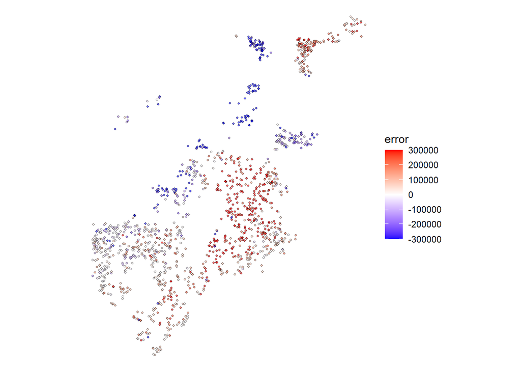

```r
library(sf)
options(scipen = 999)
# Convert boston data to sf object
boston_test <- boston_test %>%
  st_as_sf(coords = c("Longitude", "Latitude"), crs = 4326) %>%
  st_transform('ESRI:102286')  # MA State Plane (feet)


# Install if needed: install.packages("hexbin")
library(hexbin)

ggplot(boston_test) +
  geom_sf(aes(fill = error),
          shape = 21,
          size = 1,
          alpha = 0.6,
          stroke = 0.2) +
  scale_fill_gradient2(
    low = "blue",
    mid = "white",
    high = "red",
    midpoint = 0,
    limits = c(-300000, 300000),
    oob = scales::squish
  ) +
  theme_void()
```

**What to look for:**

- Blue clusters (we under-predict)
- Red clusters (we over-predict)
- Random scatter (good!)

## Scatter Plot: Spatial Lag of Errors

**Create the spatial lag:**

```r
library(spdep)

# Define neighbors (5 nearest)
coords <- st_coordinates(boston_test)
neighbors <- knn2nb(knearneigh(coords, k=5))
weights <- nb2listw(neighbors, style="W")

# Calculate spatial lag of errors
boston_test$error_lag <- lag.listw(weights, boston_test$error)
```

**Then plot:**

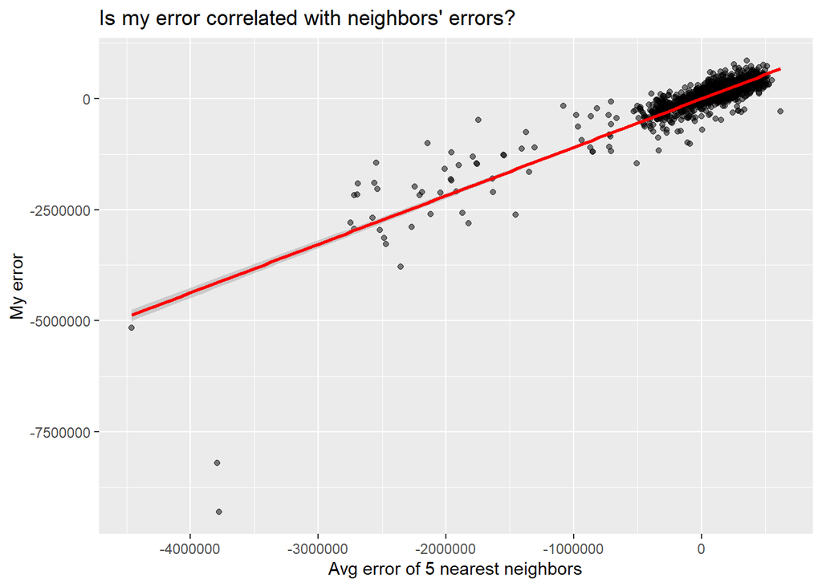

```r
ggplot(boston_test, aes(x=error_lag, y=error)) +
  geom_point(alpha=0.5) +
  geom_smooth(method="lm", color="red") +
  labs(title="Is my error correlated with neighbors' errors?",
       x="Avg error of 5 nearest neighbors",
       y="My error")
```

# Part 3: Moran’s I

## What is Moran’s I?

**Moran’s I** measures spatial autocorrelation

**Range:** -1 to +1

- **+1** = Perfect positive correlation (clustering)
- **0** = Random spatial pattern
- **-1** = Perfect negative correlation (dispersion)

**Formula (look’s scary, but its so intuitive!):**

$$I = \frac{n \sum_i \sum_j w_{ij}(x_i - \bar{x})(x_j - \bar{x})}{\sum_i \sum_j w_{ij} \sum_i (x_i - \bar{x})^2}$$

Where $w_{ij}$ = spatial weight between locations *i* and *j*

## Worked Example: Understanding the Formula

**5 houses in a row, predicting sale prices:**

| House | Actual Price | Predicted Price | Error |
| --- | --- | --- | --- |
| A | $500k | $400k | +$100k |
| B | $480k | $400k | +$80k |
| C | $420k | $400k | +$20k |
| D | $350k | $400k | -$50k |
| E | $330k | $400k | -$70k |

**Mean error = +$16k**

**The question:** Are errors for nearby houses similar to each other?

## Step 1: Calculate Deviations from Mean

**Subtract the mean error from each house’s error:**

| House | Error | Mean Error | Deviation from Mean |
| --- | --- | --- | --- |
| A | +$100k | +$16k | +$84k |
| B | +$80k | +$16k | +$64k |
| C | +$20k | +$16k | +$4k |
| D | -$50k | +$16k | -$66k |
| E | -$70k | +$16k | -$86k |

## Step 2: Multiply Neighbor Deviations

**For each neighbor pair, multiply their deviations:**

**Neighbor Pairs:**

- A-B: $(+84k) \times (+64k) = +5,376$
- B-C: $(+64k) \times (+4k) = +256$
- C-D: $(+4k) \times (-66k) = -264$
- D-E: $(-66k) \times (-86k) = +5,676$

**Sum of products = 11,044**

**What does this mean?**

**Negative product** = dissimilar neighbors  
- C-D: one over, one under

**The pattern:** High-error houses cluster together, low-error houses cluster together

## The Intuition Behind Moran’s I

**The formula is really just asking:**

> *“When I’m above/below average, are my neighbors also above/below average?”*

**Breaking it down:**

1. $(x_i - \bar{x})$ = How far is my house’s error from the mean?
2. $(x_j - \bar{x})$ = How far is my neighbor’s error from the mean?
3. **Multiply them:**
   - If both positive or both negative → **positive product** (similar)
   - If opposite signs → **negative product** (dissimilar)
4. **Sum across all neighbor pairs** and normalize

**Result:**

- Lots of positive products → **High Moran’s I** (clustering)
- Products near zero → **Low Moran’s I** (random)
- Negative products → **Negative Moran’s I** (rare with errors)

## The Intuition Behind Moran’s I

**The formula is really just asking:**

> *“When I’m above/below average, are my neighbors also above/below average?”*

**Breaking it down:**

1. $(x_i - \bar{x})$ = How far am I from the mean?
2. $(x_j - \bar{x})$ = How far is my neighbor from the mean?
3. **Multiply them:**
   - If both positive or both negative → **positive product** (similar)
   - If opposite signs → **negative product** (dissimilar)
4. **Sum across all neighbor pairs** and normalize

**Result:**

- Lots of positive products → **High Moran’s I** (clustering)
- Products near zero → **Low Moran’s I** (random)
- Negative products → **Negative Moran’s I** (rare with errors)

## Defining “Neighbors”

**Different ways to define spatial relationships:**

**Contiguity**

- Polygons that share a border
- Queen vs. Rook

**Distance**

- All within X meters
- Fixed threshold

**k-Nearest**

- Closest k points
- Adaptive distance

**For point data (houses), use k-nearest neighbors**

```r
# Create 5-nearest neighbors
coords <- st_coordinates(boston_test)
nb <- knn2nb(knearneigh(coords, k=5))
weights <- nb2listw(nb, style="W")
```

## Calculating Spatial Lag

**Spatial lag** = average value of neighbors

**TipExample: 5 houses**

[output not shown]

**In R:**

```r
boston$price_lag <- lag.listw(weights, boston$SalePrice)
```

## Computing Moran’s I

**Calculate Moran’s I for your errors:**

```r
# Test for spatial autocorrelation in errors
moran_test <- moran.mc(
  boston_test$error,        # Your errors
  weights,                  # Spatial weights matrix
  nsim = 999                # Number of permutations
)

# View results
moran_test$statistic         # Moran's I value
```

```
statistic
0.7186593
```

```r
moran_test$p.value          # Is it significant?
```

```
[1] 0.001
```

**Interpretation:**

- **I > 0** and *p* < 0.05 → Significant clustering
- **I ≈ 0** → Random pattern (good!)
- **I < 0** → Dispersion (rare with errors)

## Visualizing Significance

**Compare observed I to random permutations:**

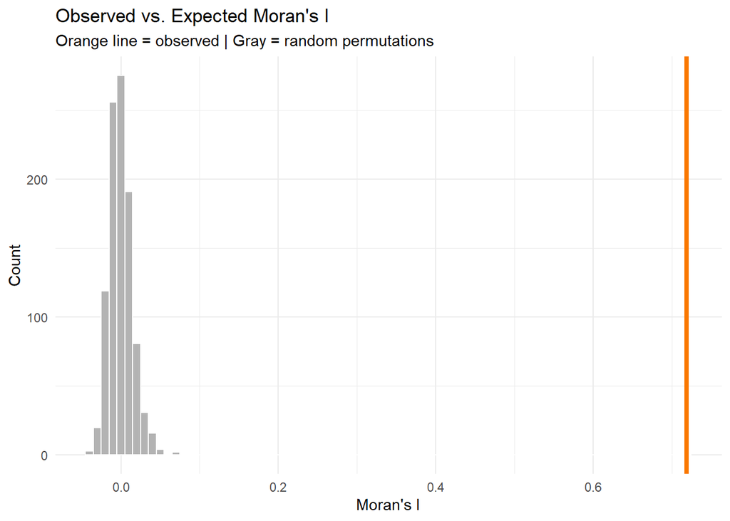

## What Moran’s I Tells You

**ImportantDecision Framework**

**If Moran’s I is high (errors clustered):**

1. Add more spatial features
   - Try different buffer sizes
   - Include more amenities/disamenities
   - Create neighborhood-specific variables
2. Try spatial fixed effects
   - Neighborhood dummies
   - Grid cell dummies
3. Consider spatial regression models
   - Spatial lag model
   - Spatial error model
   - (Advanced topic, not covered today)

**If Moran’s I ≈ 0 (random errors):**

✅ Your model adequately captures spatial relationships!

## “What About Spatial Lag/Error Models?”

*“In my spatial statistics class, I learned about spatial lag and spatial error models for dealing with spatial autocorrelation. Why aren’t we using those here?”*

### **Spatial Econometrics Models**

**(Spatial Statistics Class)**

**Spatial Lag Model:** $Y_i = \rho WY + \beta X_i + \varepsilon$

**Spatial Error Model:** $Y_i = \beta X_i + \lambda W\varepsilon + \xi$

**Purpose:**

- Causal inference with spatial spillovers
- Understanding neighbor effects
- Correct standard errors for hypothesis testing
- Cross-sectional analysis

**When to use:** Academic research on spillover effects, peer influence, regional economics

### **Predictive Spatial Features**

**(This Class)**

**Our Approach:**
$$Y_i = \beta_0 + \beta_1 X_i + \beta_2(\text{crimes}_{500ft}) + \beta_3(\text{dist}_{downtown}) + \varepsilon_i$$

**Purpose:**

- Out-of-sample prediction
- Forecasting new observations
- Applied machine learning
- Generalization to new areas

**When to use:** Real estate prediction, housing market forecasting, policy planning

## Why Not Spatial Lag Models for Prediction?

### **The Problems with Spatial Lag for Prediction:**

**1. Simultaneity Problem**

- Including $WY$ (neighbor prices) creates circular logic
- My price affects neighbors → neighbors affect me
- OLS estimates are **biased and inconsistent**

**2. Prediction Paradox**

- Need neighbors’ prices to predict my price
- But for new developments or future periods, those prices **don’t exist yet**
- Can’t generalize to truly new areas

**3. Data Leakage in CV**

- Geographic CV holds out spatial regions
- Spatial lag “leaks” information from test set
- Artificially good performance that won’t hold

### **Our Solution: Spatial Features of X (Not Y)**

Instead of modeling dependence in **Y** (prices), model proximity in **X** (predictors)

| ❌ Spatial Lag | ✅ Our Approach |
| --- | --- |
| “Near expensive houses” | “Near low crime areas” |
| Uses neighbor **prices** | Uses neighbor **characteristics** |
| Circular logic | Causal mechanism |
| Can’t predict new areas | Generalizes well |

**If Moran’s I shows clustered errors:**

✅ **Add more spatial features** (different buffers, more amenities)  
✅ **Try neighborhood fixed effects**  
✅ **Use spatial cross-validation**

❌ Don’t add spatial lag of Y for prediction purposes

**Tip**The Bottom Line**

Both approaches are valid for different goals! Match method to purpose: **inference** → spatial lag/error models; **prediction** → spatial features.

## Quick Clarification: Biased vs. Inconsistent

When we say OLS estimates are **“biased and inconsistent”** with spatial lag models, what does that mean?

### **Biased Estimator**

**Definition:** Expected value ≠ true parameter

$$E[\hat{\beta}] \neq \beta$$

**What this means:**

- On average, across all possible samples, your estimate is **systematically wrong**
- Doesn’t get the right answer even in expectation
- More data doesn’t fix it

**Example:**

- True effect: β = 100
- Your estimates average to: 80
- You’re systematically **20 units off**

### **Inconsistent Estimator**

**Definition:** Doesn’t converge to true value as n → ∞

$$\hat{\beta} \not\to \beta \text{ as } n \to \infty$$

**What this means:**

- Even with **infinite data**, you won’t get the right answer
- The problem doesn’t go away with bigger samples
- Violates a fundamental property of good estimators

**Example:** - n = 100 → estimate = 80 - n = 10,000 → estimate = 82 - n = 1,000,000 → estimate = 84 - Never reaches true value of 100

# Summary & Next Steps

## Key Takeaways

**Spatial autocorrelation in errors indicates model misspecification**

**Moran’s I is a diagnostic tool:**

- Global I: overall clustering
- Maps of residuals give clues to what you might be missing

**Iterative improvement:**

- Diagnose → Engineer features → Re-test → Repeat
- Document what you try!

## Resources

**Spatial autocorrelation:** - https://mgimond.github.io/Spatial/spatial-autocorrelation.html

**spdep package:** - https://r-spatial.github.io/spdep/

# Questions Before Work Time?

Come see me during the work session for:

- Help with Moran’s I calculation
- Ideas for new spatial features
- Debugging code issues
- Discussing your model strategy